# 3-phase controlled rectifier

The DC side of a three-phase thyristor converter is connected to a constant current load. If the converter is operated at a firing angle of $60^\circ$, determine the duration for which each thyristor will be reverse biased in a fundamental period. Repeat for $90^\circ$ and $150^\circ$.

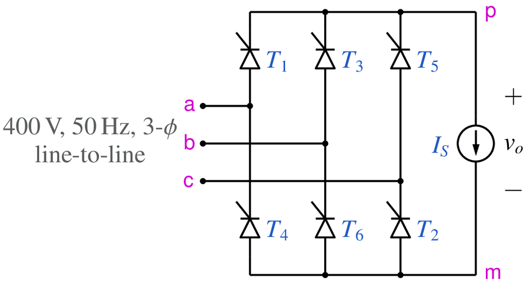

```python
from IPython.display import Image
Image(filename =r'controlled_rectifier_3ph_6_fig_1.png', width=420)
```

```python
# run this cell to view the circuit file.
%pycat controlled_rectifier_3ph_6_orig.in
```

We now replace the strings such as `\$alpha` with the values of our choice by running the python script given below. It takes an existing circuit file `controlled_rectifier_3ph_6_orig.in` and produces a new circuit file `controlled_rectifier_3ph_6.in`, after replacing `\$alpha` (etc) with values of our choice.

```python
import gseim_calc as calc
import numpy as np

s_alpha = "90" # to be changed by user

VL = 400.0
A_sin = VL*np.sqrt(2/3)

s_A_sin = ("%11.4E"%(A_sin)).strip()

l = [
  ('$alpha', s_alpha),
  ('$A_sin', s_A_sin),
]
calc.replace_strings_1("controlled_rectifier_3ph_6_orig.in", "controlled_rectifier_3ph_6.in", l)
print('controlled_rectifier_3ph_6.in is ready for execution')
```

```
controlled_rectifier_3ph_6.in is ready for execution
```

**Execute the following cell to run GSEIM on controlled_rectifier_3ph_6.in.**

```python
import os
import dos_unix
# uncomment for windows:
#dos_unix.d2u("controlled_rectifier_3ph_6.in")
os.system('run_gseim controlled_rectifier_3ph_6.in')
```

```
Circuit: filename = controlled_rectifier_3ph_6.in
main: calling solve_trns
Transient simulation starts...
i=0
i=1000
i=2000
i=3000
GSEIM: Program completed.
```

```
0
```

The circuit file (`controlled_rectifier_3ph_6.in`) is created in the same directory as that used for launching Jupyter notebook. The last step (i.e., running `GSEIM` on `controlled_rectifier_3ph_6.in`) creates data files called `controlled_rectifier_3ph_6_1.dat`, etc. in the same directory. We can now use the python code below to compute/plot the various quantities of interest.

```
filename: controlled_rectifier_3ph_6_2.dat
filename: controlled_rectifier_3ph_6_3.dat
average value of v_o: -3.2921E-03
```

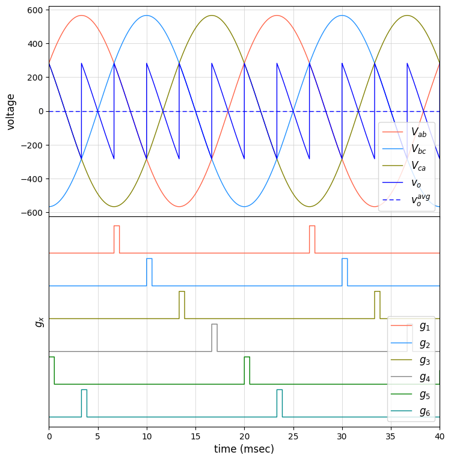

```python
import numpy as np
import matplotlib.pyplot as plt
import gseim_calc as calc
from setsize import set_size

f_hz = 50.0
T = 1.0/f_hz

slv = calc.slv("controlled_rectifier_3ph_6.in")

i_slv = 0
i_out = 1
filename = slv.l_filename_all[i_slv][i_out]
print('filename:', filename)
u1 = np.loadtxt(filename)
t1 = u1[:, 0]

v_o = slv.get_array_double(i_slv,i_out,"v_o",u1)
Vab = slv.get_array_double(i_slv,i_out,"Vab",u1)
Vbc = slv.get_array_double(i_slv,i_out,"Vbc",u1)
Vca = slv.get_array_double(i_slv,i_out,"Vca",u1)

i_out = 2
filename = slv.l_filename_all[i_slv][i_out]
print('filename:', filename)
u2 = np.loadtxt(filename)
t2 = u2[:, 0]

g1 = slv.get_array_double(i_slv,i_out,"g1",u2)
g2 = slv.get_array_double(i_slv,i_out,"g2",u2)
g3 = slv.get_array_double(i_slv,i_out,"g3",u2)
g4 = slv.get_array_double(i_slv,i_out,"g4",u2)
g5 = slv.get_array_double(i_slv,i_out,"g5",u2)
g6 = slv.get_array_double(i_slv,i_out,"g6",u2)

l_v_o = calc.avg_rms_3a(t1, v_o, 0, 2.0*T, 1.0e-5*T)

print('average value of v_o:', "%11.4E"%l_v_o[0])

fig, ax = plt.subplots(2, sharex=False)
plt.subplots_adjust(wspace=0, hspace=0.0)

set_size(6.5, 7, ax[0])

for i in range(2):
    ax[i].set_xlim(left=0.0, right=2.0*T*1e3)
    ax[i].grid(color='#CCCCCC', linestyle='solid', linewidth=0.5)

ax[0].set_ylabel(r'voltage', fontsize=12)
ax[1].set_ylabel(r'$g_x$'  , fontsize=12)

ax[0].tick_params(labelbottom=False)

color1 = "tomato"
color2 = "dodgerblue"
color3 = "olive"
color4 = "blue"
color5 = "grey"
color6 = "green"
color7 = "darkcyan"

ax[0].plot(t1*1e3, Vab, color=color1, linewidth=1.0, label="$V_{ab}$")
ax[0].plot(t1*1e3, Vbc, color=color2, linewidth=1.0, label="$V_{bc}$")
ax[0].plot(t1*1e3, Vca, color=color3, linewidth=1.0, label="$V_{ca}$")
ax[0].plot(t1*1e3, v_o, color=color4, linewidth=1.0, label="$v_o$")

ax[0].axhline(y=l_v_o[0], color=color4, linewidth=1.0, label="$v_o^{avg}$", linestyle='--', dashes=(5,3))

ax[1].plot(t2*1e3, (g1      ), color=color1, linewidth=1.0, label="$g_1$")
ax[1].plot(t2*1e3, (g2 - 1.2), color=color2, linewidth=1.0, label="$g_2$")
ax[1].plot(t2*1e3, (g3 - 2.4), color=color3, linewidth=1.0, label="$g_3$")
ax[1].plot(t2*1e3, (g4 - 3.6), color=color5, linewidth=1.0, label="$g_4$")
ax[1].plot(t2*1e3, (g5 - 4.8), color=color6, linewidth=1.0, label="$g_5$")
ax[1].plot(t2*1e3, (g6 - 6.0), color=color7, linewidth=1.0, label="$g_6$")

ax[1].set_xlabel('time (msec)', fontsize=12)
ax[1].tick_params(left = False)
ax[1].set_yticks([])

for i in range(2):
    ax[i].legend(loc = 'lower right',frameon = True, fontsize = 10, title = None,
      markerfirst = True, markerscale = 1.0, labelspacing = 0.5, columnspacing = 2.0,
      prop = {'size' : 12})

#plt.tight_layout()
plt.show()
```

```
filename: controlled_rectifier_3ph_6_1.dat
```

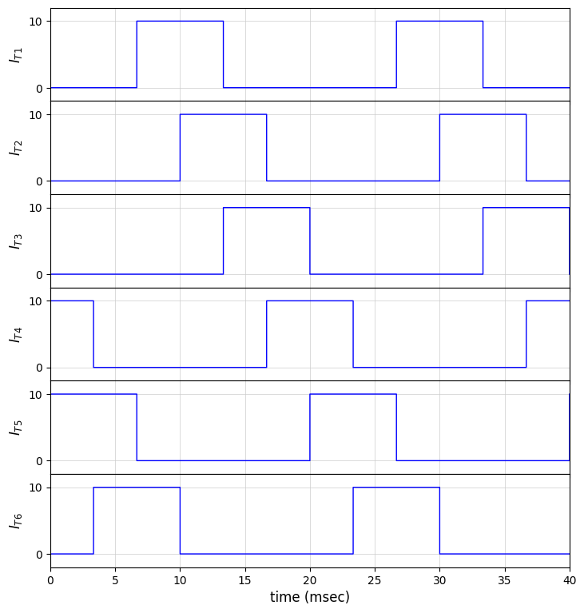

```python
import numpy as np
import matplotlib.pyplot as plt
import gseim_calc as calc
from setsize import set_size

f_hz = 50.0
T = 1.0/f_hz

slv = calc.slv("controlled_rectifier_3ph_6.in")

i_slv = 0
i_out = 0
filename = slv.l_filename_all[i_slv][i_out]
print('filename:', filename)
u1 = np.loadtxt(filename)
t1 = u1[:, 0]

IT1 = slv.get_array_double(i_slv,i_out,"IT1",u1)
IT2 = slv.get_array_double(i_slv,i_out,"IT2",u1)
IT3 = slv.get_array_double(i_slv,i_out,"IT3",u1)
IT4 = slv.get_array_double(i_slv,i_out,"IT4",u1)
IT5 = slv.get_array_double(i_slv,i_out,"IT5",u1)
IT6 = slv.get_array_double(i_slv,i_out,"IT6",u1)

fig, ax = plt.subplots(6, sharex=False)
plt.subplots_adjust(wspace=0, hspace=0.0)

set_size(6.5, 7, ax[0])

for i in range(6):
    ax[i].set_xlim(left=0.0, right=2.0*T*1e3)
    ax[i].grid(color='#CCCCCC', linestyle='solid', linewidth=0.5)
    ax[i].set_yticks([0.0, 10.0])
    ax[i].set_ylim(bottom=-2.0, top=12.0)

ax[0].set_ylabel(r'$I_{T1}$', fontsize=12)
ax[1].set_ylabel(r'$I_{T2}$', fontsize=12)
ax[2].set_ylabel(r'$I_{T3}$', fontsize=12)
ax[3].set_ylabel(r'$I_{T4}$', fontsize=12)
ax[4].set_ylabel(r'$I_{T5}$', fontsize=12)
ax[5].set_ylabel(r'$I_{T6}$', fontsize=12)

for k in range(5):
    ax[k].tick_params(labelbottom=False)

color1 = "blue"

ax[0].plot(t1*1e3, IT1, color=color1, linewidth=1.0, label="$I_{T1}$")
ax[1].plot(t1*1e3, IT2, color=color1, linewidth=1.0, label="$I_{T2}$")
ax[2].plot(t1*1e3, IT3, color=color1, linewidth=1.0, label="$I_{T3}$")
ax[3].plot(t1*1e3, IT4, color=color1, linewidth=1.0, label="$I_{T4}$")
ax[4].plot(t1*1e3, IT5, color=color1, linewidth=1.0, label="$I_{T5}$")
ax[5].plot(t1*1e3, IT6, color=color1, linewidth=1.0, label="$I_{T6}$")

ax[5].set_xlabel('time (msec)', fontsize=12)

#plt.tight_layout()
plt.show()
```

```
filename: controlled_rectifier_3ph_6_1.dat
filename: controlled_rectifier_3ph_6_2.dat
angle of reverse bias for T1:  119.95 deg.
angle of reverse bias for T2:  119.95 deg.
angle of reverse bias for T3:  120.09 deg.
angle of reverse bias for T4:  119.95 deg.
angle of reverse bias for T5:  119.95 deg.
angle of reverse bias for T6:  120.09 deg.
```

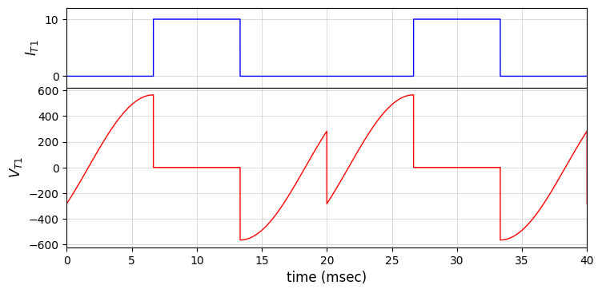

```python
import numpy as np
import matplotlib.pyplot as plt
import gseim_calc as calc
from setsize import set_size

f_hz = 50.0
T = 1.0/f_hz

slv = calc.slv("controlled_rectifier_3ph_6.in")

i_slv = 0
i_out = 0
filename = slv.l_filename_all[i_slv][i_out]
print('filename:', filename)
u1 = np.loadtxt(filename)
t1 = u1[:, 0]

IT1 = slv.get_array_double(i_slv,i_out,"IT1",u1)

i_out = 1
filename = slv.l_filename_all[i_slv][i_out]
print('filename:', filename)
u2 = np.loadtxt(filename)
t2 = u2[:, 0]

v_T1 = slv.get_array_double(i_slv,i_out,"v_T1",u2)
v_T2 = slv.get_array_double(i_slv,i_out,"v_T2",u2)
v_T3 = slv.get_array_double(i_slv,i_out,"v_T3",u2)
v_T4 = slv.get_array_double(i_slv,i_out,"v_T4",u2)
v_T5 = slv.get_array_double(i_slv,i_out,"v_T5",u2)
v_T6 = slv.get_array_double(i_slv,i_out,"v_T6",u2)

# compute durations of reverse bias:

ndiv = 5000

delt_v_T1, v_T1p = calc.interp_linear_1(t2, v_T1, ndiv)
delt_v_T2, v_T2p = calc.interp_linear_1(t2, v_T2, ndiv)
delt_v_T3, v_T3p = calc.interp_linear_1(t2, v_T3, ndiv)
delt_v_T4, v_T4p = calc.interp_linear_1(t2, v_T4, ndiv)
delt_v_T5, v_T5p = calc.interp_linear_1(t2, v_T5, ndiv)
delt_v_T6, v_T6p = calc.interp_linear_1(t2, v_T6, ndiv)

n_v_T1 = 0
n_v_T2 = 0
n_v_T3 = 0
n_v_T4 = 0
n_v_T5 = 0
n_v_T6 = 0

for k in range(ndiv):
    if (v_T1p[k] < 0.0): n_v_T1 += 1
    if (v_T2p[k] < 0.0): n_v_T2 += 1
    if (v_T3p[k] < 0.0): n_v_T3 += 1
    if (v_T4p[k] < 0.0): n_v_T4 += 1
    if (v_T5p[k] < 0.0): n_v_T5 += 1
    if (v_T6p[k] < 0.0): n_v_T6 += 1

print('angle of reverse bias for T1:', "%7.2f"%(float(n_v_T1)*delt_v_T1*360.0/(2.0*T)), 'deg.')
print('angle of reverse bias for T2:', "%7.2f"%(float(n_v_T2)*delt_v_T2*360.0/(2.0*T)), 'deg.')
print('angle of reverse bias for T3:', "%7.2f"%(float(n_v_T3)*delt_v_T3*360.0/(2.0*T)), 'deg.')
print('angle of reverse bias for T4:', "%7.2f"%(float(n_v_T4)*delt_v_T4*360.0/(2.0*T)), 'deg.')
print('angle of reverse bias for T5:', "%7.2f"%(float(n_v_T5)*delt_v_T5*360.0/(2.0*T)), 'deg.')
print('angle of reverse bias for T6:', "%7.2f"%(float(n_v_T6)*delt_v_T6*360.0/(2.0*T)), 'deg.')

fig, ax = plt.subplots(2, sharex=False,  gridspec_kw={'height_ratios': [1, 2]})
plt.subplots_adjust(wspace=0, hspace=0.0)

set_size(6.5, 3, ax[0])

for i in range(2):
    ax[i].set_xlim(left=0.0, right=2.0*T*1e3)
    ax[i].grid(color='#CCCCCC', linestyle='solid', linewidth=0.5)

ax[0].set_yticks([0.0, 10.0])
ax[0].set_ylim(bottom=-2.0, top=12.0)
ax[0].tick_params(labelbottom=False)

ax[0].set_ylabel(r'$I_{T1}$', fontsize=12)
ax[1].set_ylabel(r'$V_{T1}$', fontsize=12)

color1 = "blue"
color2 = "red"

ax[0].plot(t1*1e3, IT1 , color=color1, linewidth=1.0, label="$I_{T1}$")
ax[1].plot(t2*1e3, v_T1, color=color2, linewidth=1.0, label="$V_{T1}$")

ax[1].set_xlabel('time (msec)', fontsize=12)

#plt.tight_layout()
plt.show()
```

This notebook was contributed by **Prof. Nakul Narayanan K**, Govt. Engineering College, Thrissur. He may be contacted at nakul@gectcr.ac.in.